# 03.2 Categorical features

## Ucitavanje potrebnih biblioteka

```r
install.packages('skimr')
```

```
Error in install.packages : Updating loaded packages
```

```r
library(tidyverse)
library(skimr)
```

## Pregled podataka

Pregled svih podataka u train skupu, kako bismo uvideli koje varijable su kategorijske

```r
str(train)
```

```
'data.frame':   1200000 obs. of  21 variables:
 $ id                  : int  0 1 2 3 4 5 6 7 8 9 ...
 $ Age                 : num  19 39 23 21 21 29 41 48 21 44 ...
 $ Gender              : Factor w/ 2 levels "Female","Male": 1 1 2 2 2 2 2 1 2 2 ...
 $ Annual.Income       : num  10049 31678 25602 141855 39651 ...
 $ Marital.Status      : Factor w/ 3 levels "Divorced","Married",..: 2 1 1 2 3 2 2 1 1 2 ...
 $ Number.of.Dependents: Ord.factor w/ 5 levels "0"<"1"<"2"<"3"<..: 2 4 4 3 2 2 1 3 4 3 ...
 $ Education.Level     : Ord.factor w/ 4 levels "High School"<..: 2 3 1 2 2 2 4 1 2 3 ...
 $ Occupation          : Factor w/ 3 levels "Employed","Self-Employed",..: 2 NA 2 NA 2 NA NA 1 NA 1 ...
 $ Health.Score        : num  22.6 15.6 47.2 10.9 20.4 ...
 $ Location            : Factor w/ 3 levels "Rural","Suburban",..: 3 1 2 1 1 3 1 2 3 3 ...
 $ Policy.Type         : Factor w/ 3 levels "Basic","Comprehensive",..: 3 2 3 1 3 3 1 2 3 2 ...
 $ Previous.Claims     : Ord.factor w/ 10 levels "0"<"1"<"2"<"3"<..: 3 2 2 2 1 3 3 2 2 2 ...
 $ Vehicle.Age         : num  17 12 14 0 8 4 8 11 10 9 ...
 $ Credit.Score        : num  372 694 NA 367 598 614 807 398 685 635 ...
 $ Insurance.Duration  : Ord.factor w/ 9 levels "1"<"2"<"3"<"4"<..: 5 2 3 1 4 5 6 5 8 3 ...
 $ Policy.Start.Date   : chr  "2023-12-23 15:21:39.134960" "2023-06-12 15:21:39.111551" "2023-09-30 15:21:39.221386" "2024-06-12 15:21:39.226954" ...
 $ Customer.Feedback   : Ord.factor w/ 3 levels "Poor"<"Average"<..: 1 2 3 1 1 2 1 2 2 1 ...
 $ Smoking.Status      : Factor w/ 2 levels "No","Yes": 1 2 2 2 2 1 1 1 1 1 ...
 $ Exercise.Frequency  : Ord.factor w/ 4 levels "Rarely"<"Monthly"<..: 3 2 3 4 3 3 3 1 2 4 ...
 $ Property.Type       : Factor w/ 3 levels "Apartment","Condo",..: 3 3 3 1 3 3 3 2 2 2 ...
 $ Premium.Amount      : num  2869 1483 567 765 2022 ...
```

### 1. Gender

Osnovni opis varijable Gender za train skup:

```r
skim(train$Gender)
```

```
── Data Summary ────────────────────────
                           Values
Name                       train$Gender
Number of rows             1200000
Number of columns          1
_______________________
Column type frequency:
  factor                   1
________________________
Group variables            None
```

|  | skim_variable | n_missing | complete_rate | ordered | n_unique | top_counts |
| --- | --- | --- | --- | --- | --- | --- |
| 1 | data | 0 | 1 | FALSE | 2 | Mal: 602571, Fem: 597429 |

Osnovni opis varijable Gender za test skup:

```r
skim(test$Gender)
```

```
── Data Summary ────────────────────────
                           Values
Name                       test$Gender
Number of rows             800000
Number of columns          1
_______________________
Column type frequency:
  factor                   1
________________________
Group variables            None
```

|  | skim_variable | n_missing | complete_rate | ordered | n_unique | top_counts |
| --- | --- | --- | --- | --- | --- | --- |
| 1 | data | 0 | 1 | FALSE | 2 | Mal: 401089, Fem: 398911 |

Graficka reprezentacija podataka:

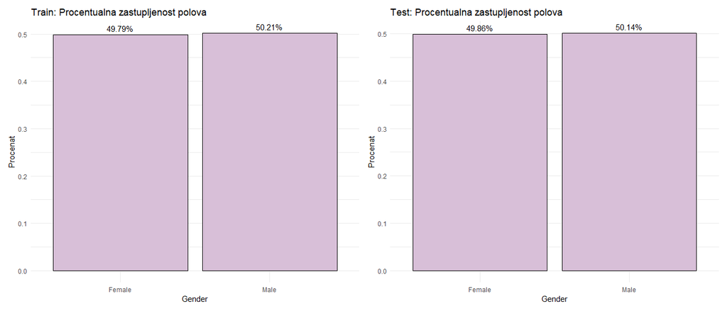

```r
plot.train <- ggplot(train, aes(x = Gender, y = ..prop.., group = 1)) +
  geom_bar(fill = "thistle", color = "black") +
  geom_text(aes(label = scales::percent(..prop..)), stat = "count", vjust = -0.5) +
  labs(title = "Train: Procentualna zastupljenost polova", x = "Gender", y = "Procenat") +
  theme_minimal()

plot.test <- ggplot(test, aes(x = Gender, y = ..prop.., group = 1)) +
  geom_bar(fill = "thistle", color = "black") +
  geom_text(aes(label = scales::percent(..prop..)), stat = "count", vjust = -0.5) +
  labs(title = "Test: Procentualna zastupljenost polova", x = "Gender", y = "Procenat") +
  theme_minimal()

plot.train | plot.test
```

### 2. Marital.Status

Osnovni opis varijable Marital.Status za train skup:

```r
skim(train$Marital.Status)
```

```
── Data Summary ────────────────────────
                           Values
Name                       train$Marital.Status
Number of rows             1200000
Number of columns          1
_______________________
Column type frequency:
  factor                   1
________________________
Group variables            None
```

|  | skim_variable | n_missing | complete_rate | ordered | n_unique | top_counts |
| --- | --- | --- | --- | --- | --- | --- |
| 1 | data | 18529 | 0.9845592 | FALSE | 3 | Sin: 395391, Mar: 394316, Div: 391764 |

Osnovni opis varijable Marital.Status za test skup:

```r
skim(test$Marital.Status)
```

```
── Data Summary ────────────────────────
                           Values
Name                       test$Marital.Status
Number of rows             800000
Number of columns          1
_______________________
Column type frequency:
  factor                   1
________________________
Group variables            None
```

|  | skim_variable | n_missing | complete_rate | ordered | n_unique | top_counts |
| --- | --- | --- | --- | --- | --- | --- |
| 1 | data | 12336 | 0.98458 | FALSE | 3 | Sin: 263705, Mar: 262172, Div: 261787 |

Graficka reprezentacija podataka

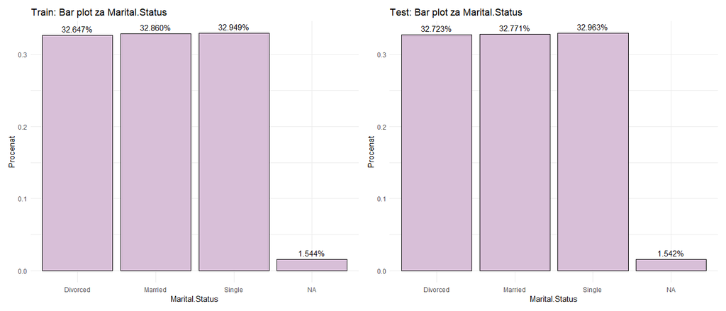

```r
plot.train <- ggplot(train, aes(x = Marital.Status, y = ..prop.., group = 1)) +
  geom_bar(fill = "thistle", color = "black") +
  geom_text(aes(label = scales::percent(..prop..)), stat = "count", vjust = -0.5) +
  labs(title = "Train: Bar plot za Marital.Status", x = "Marital.Status", y = "Procenat") +
  theme_minimal()

plot.test <- ggplot(test, aes(x = Marital.Status, y = ..prop.., group = 1)) +
  geom_bar(fill = "thistle", color = "black") +
  geom_text(aes(label = scales::percent(..prop..)), stat = "count", vjust = -0.5) +
  labs(title = "Test: Bar plot za Marital.Status", x = "Marital.Status", y = "Procenat") +
  theme_minimal()

plot.train | plot.test
```

### 3. Education.Level

Osnovni opis varijable Education.Level za train skup:

```r
skim(train$Education.Level)
```

```
── Data Summary ────────────────────────
                           Values
Name                       train$Education.Level
Number of rows             1200000
Number of columns          1
_______________________
Column type frequency:
  factor                   1
________________________
Group variables            None
```

|  | skim_variable | n_missing | complete_rate | ordered | n_unique | top_counts |
| --- | --- | --- | --- | --- | --- | --- |
| 1 | data | 0 | 1 | TRUE | 4 | Mas: 303818, PhD: 303507, Bac: 303234, Hig: 289441 |

Osnovni opis varijable Education.Level za test skup:

```r
skim(test$Education.Level)
```

```
── Data Summary ────────────────────────
                           Values
Name                       test$Education.Level
Number of rows             800000
Number of columns          1
_______________________
Column type frequency:
  factor                   1
________________________
Group variables            None
```

|  | skim_variable | n_missing | complete_rate | ordered | n_unique | top_counts |
| --- | --- | --- | --- | --- | --- | --- |
| 1 | data | 0 | 1 | TRUE | 4 | Mas: 202552, PhD: 202468, Bac: 202223, Hig: 192757 |

Graficka reprezentacija podataka

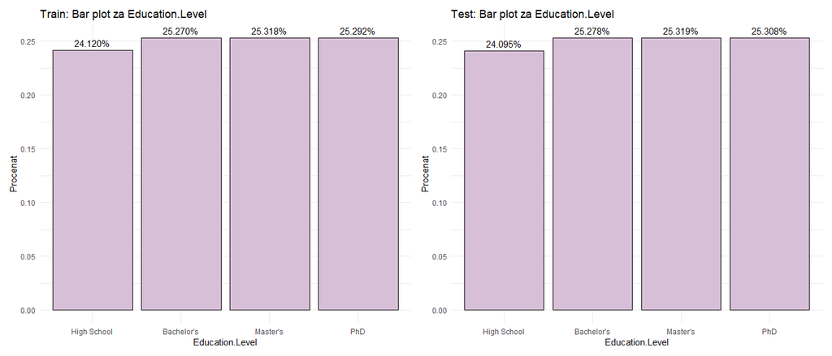

```r
plot.train <- ggplot(train, aes(x = Education.Level, y = ..prop.., group = 1)) +
  geom_bar(fill = "thistle", color = "black") +
  geom_text(aes(label = scales::percent(..prop..)), stat = "count", vjust = -0.5) +
  labs(title = "Train: Bar plot za Education.Level", x = "Education.Level", y = "Procenat") +
  theme_minimal()

plot.test <- ggplot(test, aes(x = Education.Level, y = ..prop.., group = 1)) +
  geom_bar(fill = "thistle", color = "black") +
  geom_text(aes(label = scales::percent(..prop..)), stat = "count", vjust = -0.5) +
  labs(title = "Test: Bar plot za Education.Level", x = "Education.Level", y = "Procenat") +
  theme_minimal()

plot.train | plot.test
```

### 4. Occupation

Osnovni opis varijable Occupation za train skup:

```r
skim(train$Occupation)
```

```
── Data Summary ────────────────────────
                           Values
Name                       train$Occupation
Number of rows             1200000
Number of columns          1
_______________________
Column type frequency:
  factor                   1
________________________
Group variables            None
```

|  | skim_variable | n_missing | complete_rate | ordered | n_unique | top_counts |
| --- | --- | --- | --- | --- | --- | --- |
| 1 | data | 358075 | 0.7016042 | FALSE | 3 | Emp: 282750, Sel: 282645, Une: 276530 |

Osnovni opis varijable Occupation za test skup:

```r
skim(test$Occupation)
```

```
── Data Summary ────────────────────────
                           Values
Name                       test$Occupation
Number of rows             800000
Number of columns          1
_______________________
Column type frequency:
  factor                   1
________________________
Group variables            None
```

|  | skim_variable | n_missing | complete_rate | ordered | n_unique | top_counts |
| --- | --- | --- | --- | --- | --- | --- |
| 1 | data | 239125 | 0.7010938 | FALSE | 3 | Emp: 188574, Sel: 187991, Une: 184310 |

Graficka reprezentacija podataka

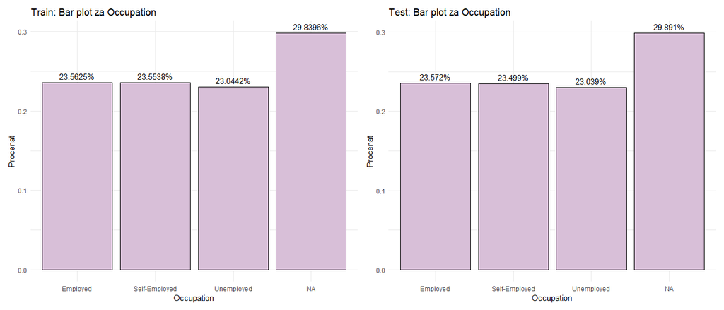

```r
plot.train <- ggplot(train, aes(x = Occupation, y = ..prop.., group = 1)) +
  geom_bar(fill = "thistle", color = "black") +
  geom_text(aes(label = scales::percent(..prop..)), stat = "count", vjust = -0.5) +
  labs(title = "Train: Bar plot za Occupation", x = "Occupation", y = "Procenat") +
  theme_minimal()

plot.test <- ggplot(test, aes(x = Occupation, y = ..prop.., group = 1)) +
  geom_bar(fill = "thistle", color = "black") +
  geom_text(aes(label = scales::percent(..prop..)), stat = "count", vjust = -0.5) +
  labs(title = "Test: Bar plot za Occupation", x = "Occupation", y = "Procenat") +
  theme_minimal()

plot.train | plot.test
```

### 5. Location

Osnovni opis varijable Location za train skup:

```r
skim(train$Location)
```

```
── Data Summary ────────────────────────
                           Values
Name                       train$Location
Number of rows             1200000
Number of columns          1
_______________________
Column type frequency:
  factor                   1
________________________
Group variables            None
```

|  | skim_variable | n_missing | complete_rate | ordered | n_unique | top_counts |
| --- | --- | --- | --- | --- | --- | --- |
| 1 | data | 0 | 1 | FALSE | 3 | Sub: 401542, Rur: 400947, Urb: 397511 |

Osnovni opis varijable Location za test skup:

```r
skim(test$Location)
```

```
── Data Summary ────────────────────────
                           Values
Name                       test$Location
Number of rows             800000
Number of columns          1
_______________________
Column type frequency:
  factor                   1
________________________
Group variables            None
```

|  | skim_variable | n_missing | complete_rate | ordered | n_unique | top_counts |
| --- | --- | --- | --- | --- | --- | --- |
| 1 | data | 0 | 1 | FALSE | 3 | Sub: 267190, Rur: 267120, Urb: 265690 |

Graficka reprezentacija podataka:

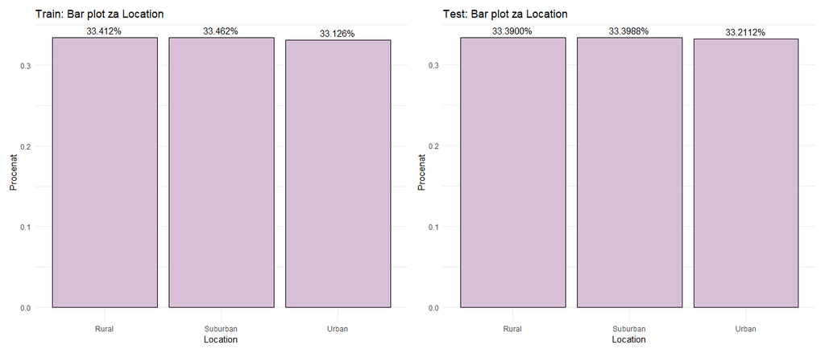

```r
plot.train <- ggplot(train, aes(x = Location, y = ..prop.., group = 1)) +
  geom_bar(fill = "thistle", color = "black") +
  geom_text(aes(label = scales::percent(..prop..)), stat = "count", vjust = -0.5) +
  labs(title = "Train: Bar plot za Location", x = "Location", y = "Procenat") +
  theme_minimal()

plot.test <- ggplot(test, aes(x = Location, y = ..prop.., group = 1)) +
  geom_bar(fill = "thistle", color = "black") +
  geom_text(aes(label = scales::percent(..prop..)), stat = "count", vjust = -0.5) +
  labs(title = "Test: Bar plot za Location", x = "Location", y = "Procenat") +
  theme_minimal()

plot.train | plot.test
```

### 6. Policy.Type

Osnovni opis varijable Policy.Type za train skup:

```r
skim(train$Policy.Type)
```

```
── Data Summary ────────────────────────
                           Values
Name                       train$Policy.Type
Number of rows             1200000
Number of columns          1
_______________________
Column type frequency:
  factor                   1
________________________
Group variables            None
```

|  | skim_variable | n_missing | complete_rate | ordered | n_unique | top_counts |
| --- | --- | --- | --- | --- | --- | --- |
| 1 | data | 0 | 1 | FALSE | 3 | Pre: 401846, Com: 399600, Bas: 398554 |

Osnovni opis varijable Policy.Type za test skup:

```r
skim(test$Policy.Type)
```

```
── Data Summary ────────────────────────
                           Values
Name                       test$Policy.Type
Number of rows             800000
Number of columns          1
_______________________
Column type frequency:
  factor                   1
________________________
Group variables            None
```

|  | skim_variable | n_missing | complete_rate | ordered | n_unique | top_counts |
| --- | --- | --- | --- | --- | --- | --- |
| 1 | data | 0 | 1 | FALSE | 3 | Pre: 267629, Com: 266222, Bas: 266149 |

Graficka reprezentacija podataka:

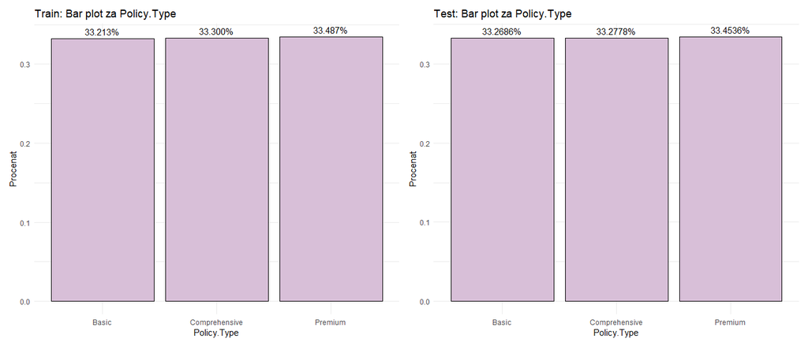

```r
plot.train <- ggplot(train, aes(x = Policy.Type, y = ..prop.., group = 1)) +
  geom_bar(fill = "thistle", color = "black") +
  geom_text(aes(label = scales::percent(..prop..)), stat = "count", vjust = -0.5) +
  labs(title = "Train: Bar plot za Policy.Type", x = "Policy.Type", y = "Procenat") +
  theme_minimal()

plot.test <- ggplot(test, aes(x = Policy.Type, y = ..prop.., group = 1)) +
  geom_bar(fill = "thistle", color = "black") +
  geom_text(aes(label = scales::percent(..prop..)), stat = "count", vjust = -0.5) +
  labs(title = "Test: Bar plot za Policy.Type", x = "Policy.Type", y = "Procenat") +
  theme_minimal()

plot.train | plot.test
```

### 7. Customer.Feedback

Osnovni opis varijable Customer.Feedback za train skup:

```r
skim(train$Customer.Feedback)
```

```
── Data Summary ────────────────────────
                           Values
Name                       train$Customer.Feedback
Number of rows             1200000
Number of columns          1
_______________________
Column type frequency:
  factor                   1
________________________
Group variables            None
```

|  | skim_variable | n_missing | complete_rate | ordered | n_unique | top_counts |
| --- | --- | --- | --- | --- | --- | --- |
| 1 | data | 77824 | 0.9351467 | TRUE | 3 | Ave: 377905, Poo: 375518, Goo: 368753 |

Osnovni opis varijable Customer.Feedback za test skup:

```r
skim(test$Customer.Feedback)
```

```
── Data Summary ────────────────────────
                           Values
Name                       test$Customer.Feedback
Number of rows             800000
Number of columns          1
_______________________
Column type frequency:
  factor                   1
________________________
Group variables            None
```

|  | skim_variable | n_missing | complete_rate | ordered | n_unique | top_counts |
| --- | --- | --- | --- | --- | --- | --- |
| 1 | data | 52276 | 0.934655 | TRUE | 3 | Ave: 251217, Poo: 250434, Goo: 246073 |

Graficka reprezentacija podataka:

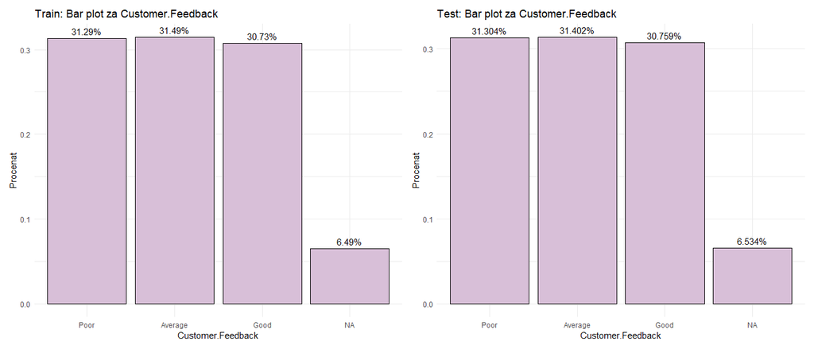

```r
plot.train <- ggplot(train, aes(x = Customer.Feedback, y = ..prop.., group = 1)) +
  geom_bar(fill = "thistle", color = "black") +
  geom_text(aes(label = scales::percent(..prop..)), stat = "count", vjust = -0.5) +
  labs(title = "Train: Bar plot za Customer.Feedback", x = "Customer.Feedback", y = "Procenat") +
  theme_minimal()

plot.test <- ggplot(test, aes(x = Customer.Feedback, y = ..prop.., group = 1)) +
  geom_bar(fill = "thistle", color = "black") +
  geom_text(aes(label = scales::percent(..prop..)), stat = "count", vjust = -0.5) +
  labs(title = "Test: Bar plot za Customer.Feedback", x = "Customer.Feedback", y = "Procenat") +
  theme_minimal()

plot.train | plot.test
```

### 8. Smoking.Status

Osnovni opis varijable Smoking.Status za train skup:

```r
skim(train$Smoking.Status)
```

```
── Data Summary ────────────────────────
                           Values
Name                       train$Smoking.Status
Number of rows             1200000
Number of columns          1
_______________________
Column type frequency:
  factor                   1
________________________
Group variables            None
```

|  | skim_variable | n_missing | complete_rate | ordered | n_unique | top_counts |
| --- | --- | --- | --- | --- | --- | --- |
| 1 | data | 0 | 1 | FALSE | 2 | Yes: 601873, No: 598127 |

Osnovni opis varijable Smoking.Status za test skup:

```r
skim(test$Smoking.Status)
```

```
── Data Summary ────────────────────────
                           Values
Name                       test$Smoking.Status
Number of rows             800000
Number of columns          1
_______________________
Column type frequency:
  factor                   1
________________________
Group variables            None
```

|  | skim_variable | n_missing | complete_rate | ordered | n_unique | top_counts |
| --- | --- | --- | --- | --- | --- | --- |
| 1 | data | 0 | 1 | FALSE | 2 | Yes: 401859, No: 398141 |

Graficka reprezentacija podataka:

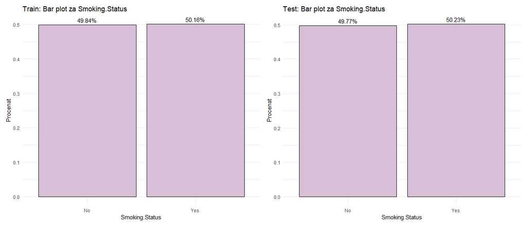

```r
plot.train <- ggplot(train, aes(x = Smoking.Status, y = ..prop.., group = 1)) +
  geom_bar(fill = "thistle", color = "black") +
  geom_text(aes(label = scales::percent(..prop..)), stat = "count", vjust = -0.5) +
  labs(title = "Train: Bar plot za Smoking.Status", x = "Smoking.Status", y = "Procenat") +
  theme_minimal()

plot.test <- ggplot(test, aes(x = Smoking.Status, y = ..prop.., group = 1)) +
  geom_bar(fill = "thistle", color = "black") +
  geom_text(aes(label = scales::percent(..prop..)), stat = "count", vjust = -0.5) +
  labs(title = "Test: Bar plot za Smoking.Status", x = "Smoking.Status", y = "Procenat") +
  theme_minimal()

plot.train | plot.test
```

### 9. Exercise.Frequency

Osnovni opis varijable Exercise.Frequency za train skup:

```r
skim(train$Exercise.Frequency)
```

```
── Data Summary ────────────────────────
                           Values
Name                       train$Exercise.Frequency
Number of rows             1200000
Number of columns          1
_______________________
Column type frequency:
  factor                   1
________________________
Group variables            None
```

|  | skim_variable | n_missing | complete_rate | ordered | n_unique | top_counts |
| --- | --- | --- | --- | --- | --- | --- |
| 1 | data | 0 | 1 | TRUE | 4 | Wee: 306179, Mon: 299830, Rar: 299420, Dai: 294571 |

Osnovni opis varijable Exercise.Frequency za test skup:

```r
skim(test$Exercise.Frequency)
```

```
── Data Summary ────────────────────────
                           Values
Name                       test$Exercise.Frequency
Number of rows             800000
Number of columns          1
_______________________
Column type frequency:
  factor                   1
________________________
Group variables            None
```

|  | skim_variable | n_missing | complete_rate | ordered | n_unique | top_counts |
| --- | --- | --- | --- | --- | --- | --- |
| 1 | data | 0 | 1 | TRUE | 4 | Wee: 204514, Rar: 200514, Mon: 198400, Dai: 196572 |

Graficka reprezentacija podataka:

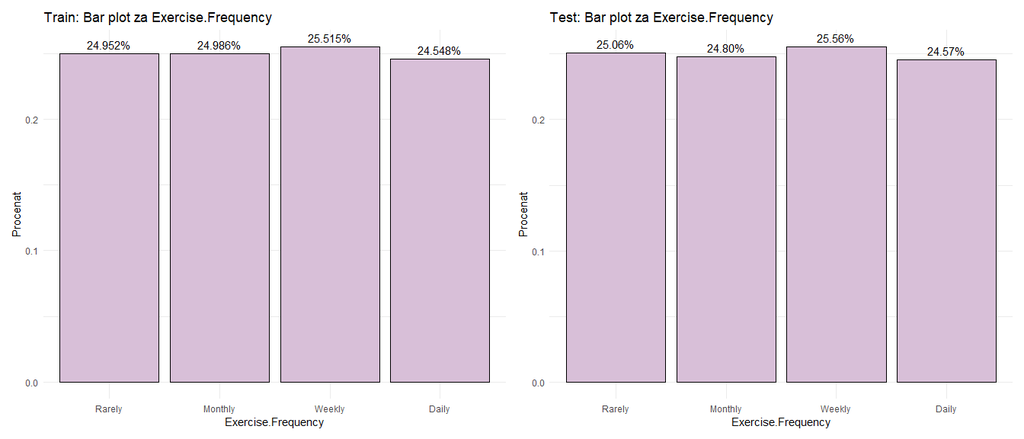

```r
plot.train <- ggplot(train, aes(x = Exercise.Frequency, y = ..prop.., group = 1)) +
  geom_bar(fill = "thistle", color = "black") +
  geom_text(aes(label = scales::percent(..prop..)), stat = "count", vjust = -0.5) +
  labs(title = "Train: Bar plot za Exercise.Frequency", x = "Exercise.Frequency", y = "Procenat") +
  theme_minimal()

plot.test <- ggplot(test, aes(x = Exercise.Frequency, y = ..prop.., group = 1)) +
  geom_bar(fill = "thistle", color = "black") +
  geom_text(aes(label = scales::percent(..prop..)), stat = "count", vjust = -0.5) +
  labs(title = "Test: Bar plot za Exercise.Frequency", x = "Exercise.Frequency", y = "Procenat") +
  theme_minimal()

plot.train | plot.test
```

### 10. Property.Type

Osnovni opis varijable Property.Type za train skup:

```r
skim(train$Property.Type)
```

```
── Data Summary ────────────────────────
                           Values
Name                       train$Property.Type
Number of rows             1200000
Number of columns          1
_______________________
Column type frequency:
  factor                   1
________________________
Group variables            None
```

|  | skim_variable | n_missing | complete_rate | ordered | n_unique | top_counts |
| --- | --- | --- | --- | --- | --- | --- |
| 1 | data | 0 | 1 | FALSE | 3 | Hou: 400349, Apa: 399978, Con: 399673 |

Osnovni opis varijable Property.Type za test skup:

```r
skim(test$Property.Type)
```

```
── Data Summary ────────────────────────
                           Values
Name                       test$Property.Type
Number of rows             800000
Number of columns          1
_______________________
Column type frequency:
  factor                   1
________________________
Group variables            None
```

|  | skim_variable | n_missing | complete_rate | ordered | n_unique | top_counts |
| --- | --- | --- | --- | --- | --- | --- |
| 1 | data | 0 | 1 | FALSE | 3 | Hou: 267151, Con: 266805, Apa: 266044 |

Graficka reprezentacija podataka:

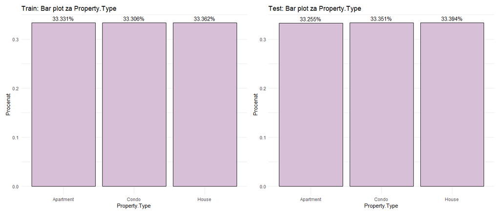

```r
plot.train <- ggplot(train, aes(x = Property.Type, y = ..prop.., group = 1)) +
  geom_bar(fill = "thistle", color = "black") +
  geom_text(aes(label = scales::percent(..prop..)), stat = "count", vjust = -0.5) +
  labs(title = "Train: Bar plot za Property.Type", x = "Property.Type", y = "Procenat") +
  theme_minimal()

plot.test <- ggplot(test, aes(x = Property.Type, y = ..prop.., group = 1)) +
  geom_bar(fill = "thistle", color = "black") +
  geom_text(aes(label = scales::percent(..prop..)), stat = "count", vjust = -0.5) +
  labs(title = "Test: Bar plot za Property.Type", x = "Property.Type", y = "Procenat") +
  theme_minimal()

plot.train | plot.test
```

## Zakljucak

- Nijedan feature nije konstantan.
- Svi nivoi u kategorijama su gotovo podjednako zastupljeni.